# {introverse} quick docs

[figure not shown]

`ggplot2::geom_histogram()`  
**`get_help()` docs**

### Description

The [`geom_histogram()`](https://ggplot2.tidyverse.org/reference/geom_histogram.html) function is part of the [`{ggplot2}`](https://ggplot2.tidyverse.org/) package, which is part of the [`{tidyverse}`](https://www.tidyverse.org/).

The `geom_histogram()` function is used within `{ggplot2}` plots to create a histogram, which shows the distribution of a *numeric continuous* variable. The x-axis shows values of the variable, and the y-axis shows binned counts of how often values in a given range occur. By default, `geom_histogram()` uses 30 bins.

#### Required aesthetics:

- `x`: The numeric variable whose distribution the histogram visualizes.
  - Note that it is also allowed to make a horizontal histogram by providing a `y` aesthetic instead of an `x` (but never both)

#### Commonly used optional aesthetics:

- `color` (`colour`): The outline color for the histogram bars
- `fill`: The fill for the histogram bars
- `size`: The width of the histogram bar outlines
- `bins`: How many bins should be used (will be overridden by `binwidth` if both are provided)
- `binwidth`: The width of each bin (will override `bins` if both are provided)

To use this function, you need to either first load the `{ggplot2}` library, or always use the function with `ggplot2::geom_histogram()` notation.

```r
# Load the library
library(ggplot2)
# Or, load the full tidyverse:
library(tidyverse)

# Or, use :: notation
ggplot2::geom_histogram()
```

### Examples

The examples below use the `msleep` dataset. Learn more about this dataset with `get_help("msleep")`.

```r
# Show the msleep dataset with head()
head(msleep)
```

```
## # A tibble: 6 × 11
##   name  genus vore  order conservation sleep_total sleep_rem sleep_cycle awake  brainwt  bodywt
##   <chr> <chr> <chr> <chr> <chr>              <dbl>     <dbl>       <dbl> <dbl>    <dbl>   <dbl>
## 1 Owl … Aotus omni  Prim… <NA>                17         1.8      NA       7    0.0155    0.48
## 2 Moun… Aplo… herbi Rode… nt                  14.4       2.4      NA       9.6 NA         1.35
## 3 Grea… Blar… omni  Sori… lc                  14.9       2.3       0.133   9.1  0.00029   0.019
## 4 Cow   Bos   herbi Arti… domesticated         4         0.7       0.667  20    0.423   600
## 5 Thre… Brad… herbi Pilo… <NA>                14.4       2.2       0.767   9.6 NA         3.85
## 6 Nort… Call… carni Carn… vu                   8.7       1.4       0.383  15.3 NA        20.5
```

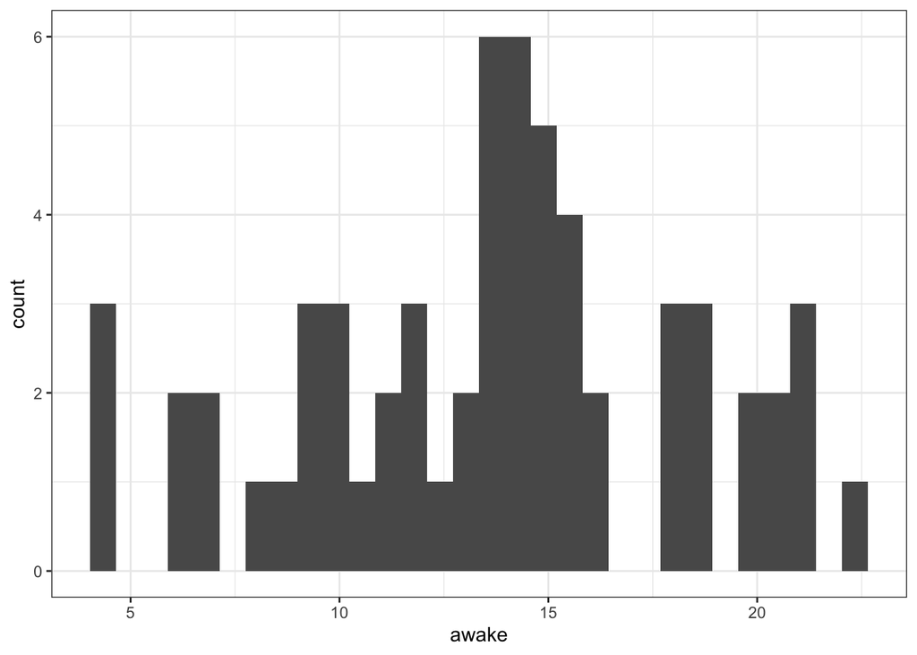

```r
# By default, histograms have no color outline, are filled with dark gray, and use 30 bins
# If you do not specify binning, you will get a _normal_ message telling you 30 were chosen
ggplot(msleep) +
  aes(x = awake) +
  geom_histogram()
```

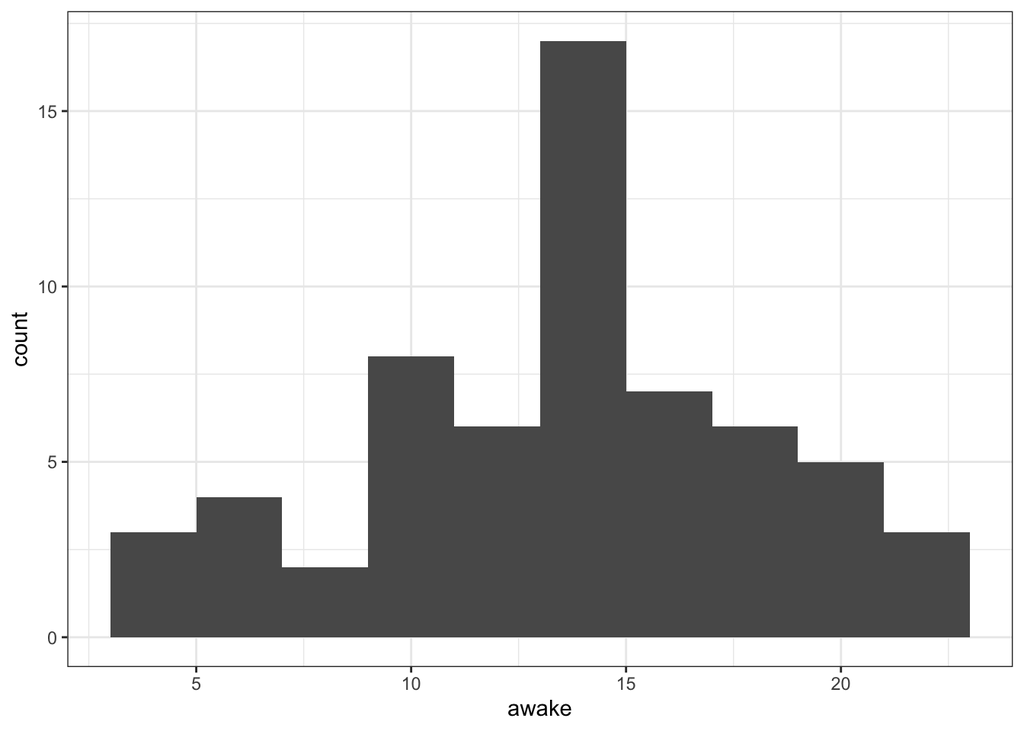

```r
# Change the binning with `bins`
ggplot(msleep) +
  aes(x = awake) +
  geom_histogram(bins = 10)
```

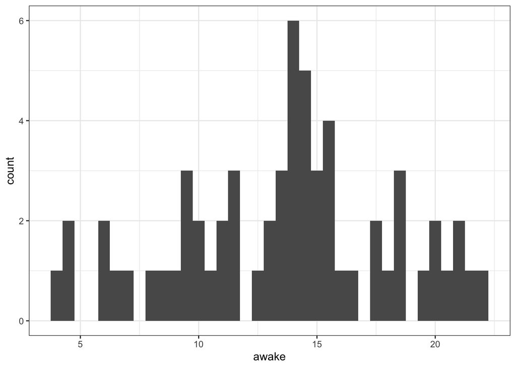

```r
# Change the binning with `binwidth`
ggplot(msleep) +
  aes(x = awake) +
  geom_histogram(binwidth = 0.5)
```

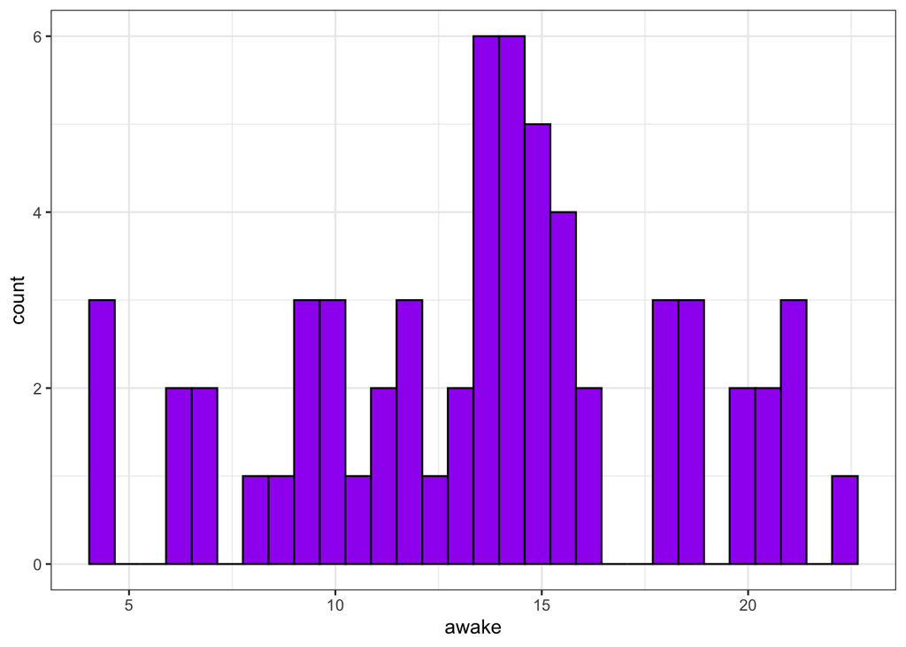

```r
# Include custom fill and color
ggplot(msleep) +
  aes(x = awake) +
  geom_histogram(color = "black", fill = "purple")
```

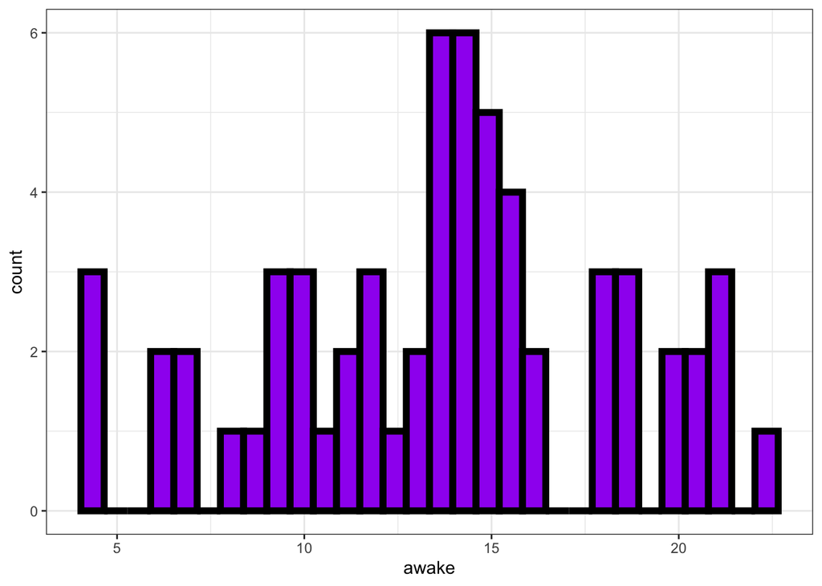

```r
# Include custom fill and color, with a larger outline size
# When you have many arguments, placing on separate lines makes code easier to read and work with
ggplot(msleep) +
  aes(x = awake) +
  geom_histogram(color = "black",
                 fill = "purple",
                 size = 2)
```

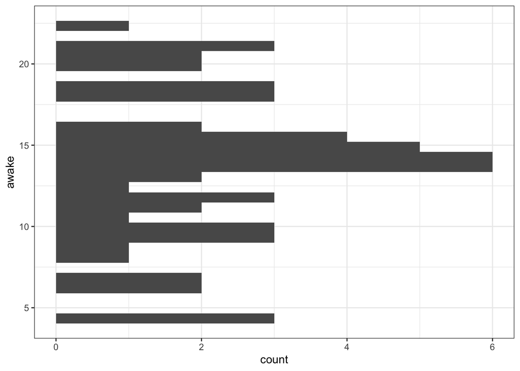

```r
# A horizontal histogram using y instead of x aesthetic
ggplot(msleep) +
  aes(y = awake) +
  geom_histogram()
```